# Distribution of max, min and ranges for a sequence of uniform rv’s

João Neto

October, 2014

Refs:

- http://observations.rene-grothmann.de/distribution-of-minima-and-maxima-and-spreads/
- http://www.johndcook.com/blog/2014/10/24/sample-range/

Say we have $n$ iid uniform rvs

$X_i \sim U(0,1), i=1 \ldots n$

The cdf of their minimum $Y=\min(X_1,\ldots, X_n)$ is:

$\begin{array}{lclr} p(Y \leq x) & = & 1 - p(Y \geq x) & \\ & = & 1- \prod_{i=1}^n p(X_i \geq x) & \color{blue}{ Y = \min(X_i) } \\ & = & 1- p(X \geq x)^n & \color{blue}{ X_i~\text{iid}~ X \sim U(0,1) } \\ & = & 1- (1-p(X \leq x))^n & \\ & = & 1- (1-x)^n & \color{blue}{ p(X \leq x) = x } \\ \end{array}$

Thus the pdf for $Y$ is

$f_Y(x) = \frac{d}{dx} P(Y \leq x) = n(1-x)^{n-1}$

We can make a simulation to confirm this result:

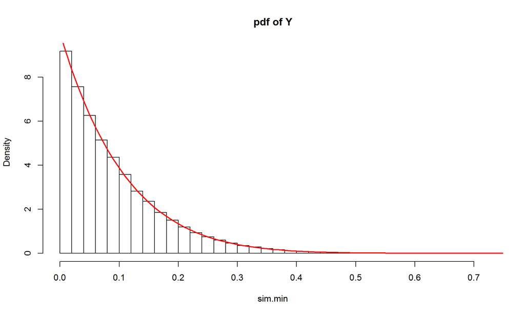

```r
n <- 10

pdf.min <- function(x) {    # pdf function for the minimum
  n*(1-x)^(n-1)
}

sample.min <-  function() { # miminum of sample with n U(0,1) rvs
  min(runif(n))
}

sim.min <- replicate(1e5, sample.min()) # simulation

hist(sim.min, breaks=50, prob=T, main="pdf of Y")
curve(pdf.min, 0, 1, col="red", lwd=2, add=T)
```

The maximum $Z = \max(X_1,\ldots, X_n)$ has similar development:

$\begin{array}{lclr} p(Z \leq x) & = & \prod_{i=1}^n p(X_i \geq x) & \\ & = & x^n & \color{blue}{ p(X \leq x) = x } \\ \end{array}$

so, the pdf of $Z$ is

$f_Z(x) = nx^{n-1}$

Again:

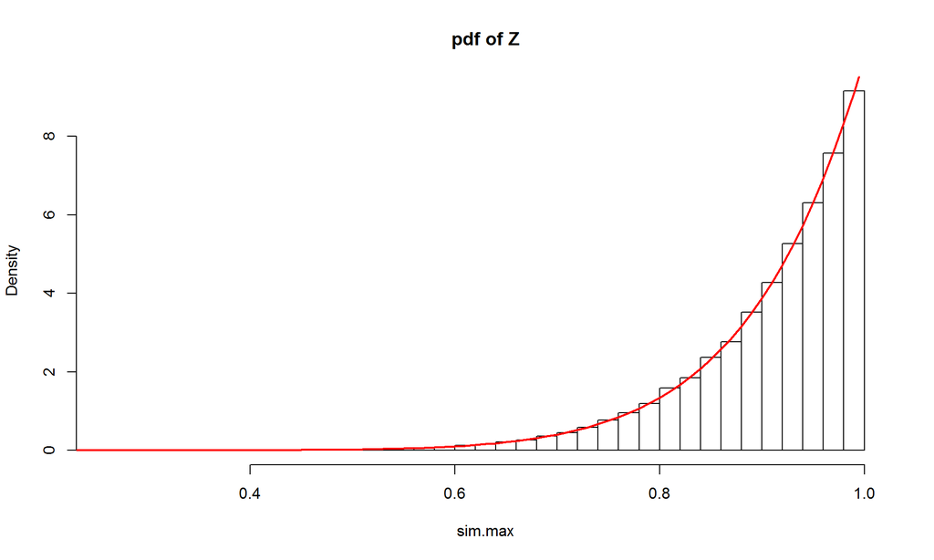

```r
n <- 10

pdf.max <- function(x) {    # pdf function for the minimum
  n*x^(n-1)
}

sample.max <-  function() { # miminum of sample with n U(0,1) rvs
  max(runif(n))
}

sim.max <- replicate(1e5, sample.max()) # simulation

hist(sim.max, breaks=50, prob=T, main="pdf of Z")
curve(pdf.max, 0, 1, col="red", lwd=2, add=T)
```

The distribution of the range $R=Z-Y$ of these $n$ values should be something like this:

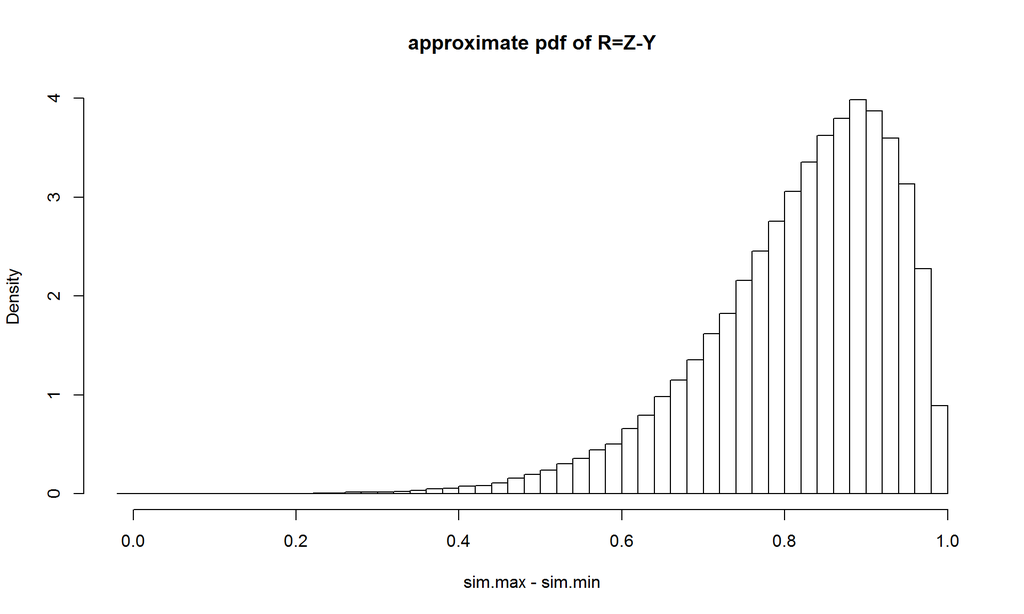

```r
hist(sim.max-sim.min, breaks=50, prob=T, main="approximate pdf of R=Z-Y")
```

which resembles a beta distribution. But is it? Notice that the true pdf for $R$ is not the difference $Z-Y$ because they are not independent. To compute $R$’s cdf we assume that $x$ is the minimum value and the range is $d$.

There are two mutually exclusive events:

- $x<1-d$ so that we have a range $[x,x+d]$. This means two events happening, the minimum $Y=x$ and all the remaining $n-1$ points are within the interval which has length $d/(1-x)$, let’s call this event $W$.
- $x>1-d$ so that we have range $[x,1]$, ie, the minimum $Y \geq 1-d$, ie, all $n$ points are within a range $d$.

$\begin{array}{lclr} p(R \leq d) & = & \int_0^{1-d} f_Y(x) p(W) dx + p(Y \geq 1-d) & \\ & = & \int_0^{1-d} n(1-x)^{n-1} \left( \frac{d}{1-x} \right) ^{n-1} dx + d^n & \\ & = & \int_0^{1-d} n d^{n-1} dx + d^n & \\ & = & n d^{n-1} (1-d) + d^n & \\ \end{array}$

To find the pdf:

$f_R(x) = \frac{d}{dx} n x^{n-1} (1-x) + x^n = (1-x) x^{n-2} (n-1) n$

We see that $R \sim \text{Beta}(n-1,2)$

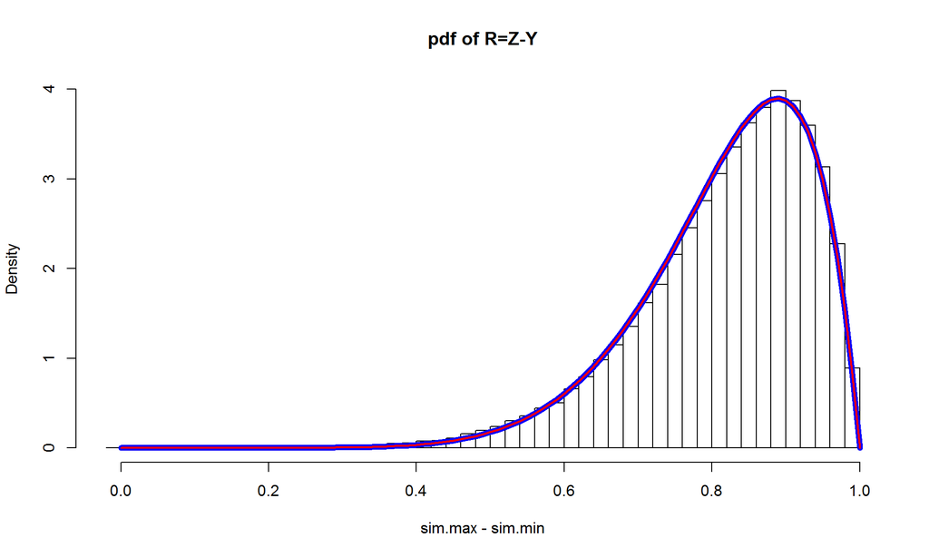

```r
pdf.range <- function(x) {
  (1-x)*x^(n-2)*(n-1)*n
}

pdf.beta <- function(x) dbeta(x,n-1,2)

hist(sim.max-sim.min, breaks=50, prob=T, main="pdf of R=Z-Y")
curve(pdf.range, 0, 1, col="blue", lwd=6, add=T)
curve(pdf.beta,  0, 1, col="red",  lwd=2, add=T)
```

If we ask what is the probability for a sample range to be greater than a value $c$, we need to compute $p(R \geq c)$

$\int_c^1 n(n-1)x^{n-2}(1-x) dx = 1 - c^{n-1} (n-c(n-1))$

We can ask now what should the minimum $n$ be so that the probability is greater than $0.5$ for the sample range to be $90\%$ of total range, ie, $c=0.9$.

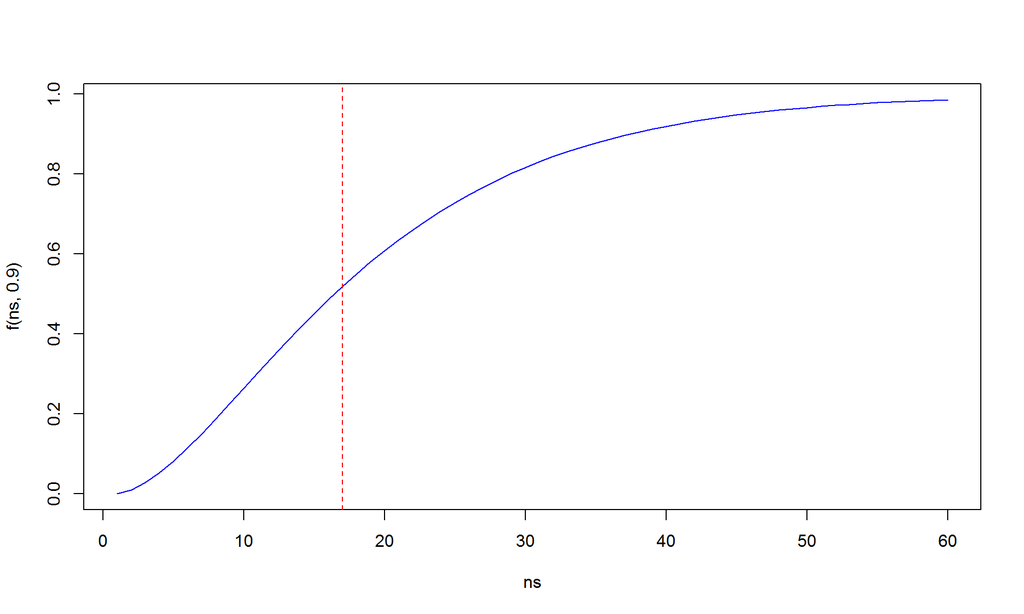

```r
f <- function(n,c) {
  1 - c^(n-1)*(n-c*(n-1))
}

ns <- 1:60
plot(ns,f(ns,.9), type="l", col="blue")
n <- which(f(ns,.9)>0.5)[1]
abline(v=n, lty=2, col="red")
```

We need n=17 samples.